# Sparsifying priors and variable selection

Peter Ralph

4 February 2020 – Advanced Biological Statistics

# Variable selection

## Example data

from Efron, Hastie, Johnstone, & Tibshirani

```r
library(lars)
data(diabetes)
class(diabetes$x2) <- "matrix"
```

```
diabetes                 package:lars                  R Documentation

Blood and other measurements in diabetics

Description:

     The ‘diabetes’ data frame has 442 rows and 3 columns. These are
     the data used in the Efron et al "Least Angle Regression" paper.

Format:

     This data frame contains the following columns:

     x a matrix with 10 columns

     y a numeric vector

     x2 a matrix with 64 columns
```

The dataset has

- 442 diabetes patients
- 10 main variables: age, gender, body mass index, average blood pressure (map), and six blood serum measurements (tc, ldl, hdl, tch, ltg, glu)
- 45 interactions, e.g. `age:ldl`
- 9 quadratic effects, e.g. `age^2`
- measure of disease progression taken one year later: `y`

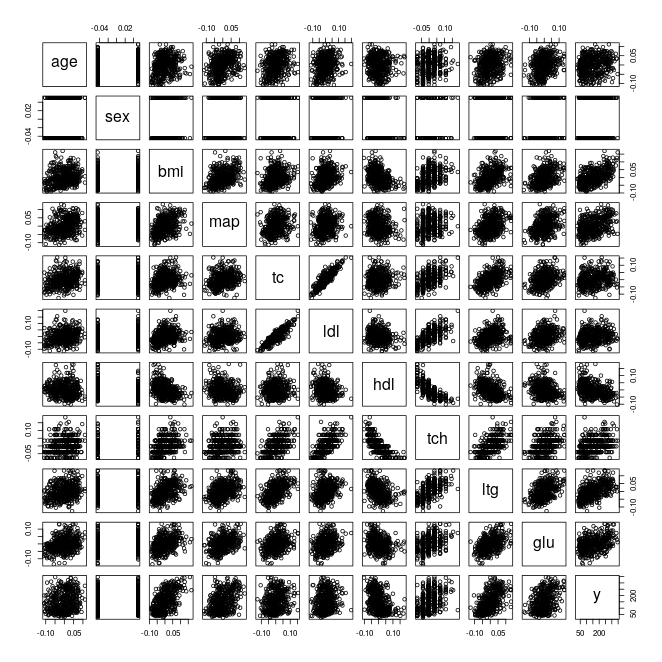

```r
cor(cbind(diabetes$x, y=diabetes$y))
```

```
##        age    sex    bmi   map    tc   ldl    hdl   tch   ltg   glu      y
## age  1.000  0.174  0.185  0.34 0.260  0.22 -0.075  0.20  0.27  0.30  0.188
## sex  0.174  1.000  0.088  0.24 0.035  0.14 -0.379  0.33  0.15  0.21  0.043
## bmi  0.185  0.088  1.000  0.40 0.250  0.26 -0.367  0.41  0.45  0.39  0.586
## map  0.335  0.241  0.395  1.00 0.242  0.19 -0.179  0.26  0.39  0.39  0.441
## tc   0.260  0.035  0.250  0.24 1.000  0.90  0.052  0.54  0.52  0.33  0.212
## ldl  0.219  0.143  0.261  0.19 0.897  1.00 -0.196  0.66  0.32  0.29  0.174
## hdl -0.075 -0.379 -0.367 -0.18 0.052 -0.20  1.000 -0.74 -0.40 -0.27 -0.395
## tch  0.204  0.332  0.414  0.26 0.542  0.66 -0.738  1.00  0.62  0.42  0.430
## ltg  0.271  0.150  0.446  0.39 0.516  0.32 -0.399  0.62  1.00  0.46  0.566
## glu  0.302  0.208  0.389  0.39 0.326  0.29 -0.274  0.42  0.46  1.00  0.382
## y    0.188  0.043  0.586  0.44 0.212  0.17 -0.395  0.43  0.57  0.38  1.000
```

## Crossvalidation plan

1. Put aside 20% of the data for *testing*.
2. Refit the model.
3. Predict the test data; compute
   $$\begin{aligned}
   S = \sqrt{\frac{1}{M} \sum_{k=1}^M (\hat y_i - y_i)^2}
   \end{aligned}$$
4. Repeat for the other four 20%s.
5. Compare.

## Crossvalidation

First let’s split the data into testing and training just once:

```r
test_indices <- (rbinom(length(diabetes$y), size=1, prob=0.2) == 1)
test_d <- cbind(data.frame(y=diabetes$y[test_indices]),
                diabetes$x2[test_indices,])
training_d <- cbind(data.frame(y=diabetes$y[!test_indices]),
                diabetes$x2[!test_indices,])
```

## Ordinary linear regression

```r
ols <- lm(y ~ ., data=training_d)
summary(ols)
```

```
##
## Call:
## lm(formula = y ~ ., data = training_d)
##
## Residuals:
##    Min     1Q Median     3Q    Max
## -144.3  -32.5   -1.1   30.8  150.4
##
## Coefficients:
##              Estimate Std. Error t value Pr(>|t|)
## (Intercept)   150.688      2.952   51.04  < 2e-16 ***
## age            84.949     76.868    1.11  0.27004
## sex          -269.634     74.608   -3.61  0.00036 ***
## bmi           472.782     95.168    4.97  1.2e-06 ***
## map           360.868     83.425    4.33  2.1e-05 ***
## tc          -5344.136  61836.313   -0.09  0.93119
## ldl          4723.000  54348.535    0.09  0.93081
## hdl          1680.538  23107.326    0.07  0.94207
## tch           -85.184    310.280   -0.27  0.78387
## ltg          2350.565  20327.550    0.12  0.90802
## glu            89.653     82.363    1.09  0.27730
## `age^2`        66.327     81.718    0.81  0.41767
## `bmi^2`       -15.807     98.076   -0.16  0.87207
## `map^2`       -52.390     81.903   -0.64  0.52291
## `tc^2`       4501.315   7881.979    0.57  0.56839
## `ldl^2`      1315.348   5909.806    0.22  0.82403
## `hdl^2`      1030.418   1782.583    0.58  0.56369
## `tch^2`      1153.506    714.697    1.61  0.10764
## `ltg^2`      1092.080   1792.281    0.61  0.54280
## `glu^2`       128.336    105.649    1.21  0.22547
## `age:sex`     148.196     90.659    1.63  0.10323
## `age:bmi`       0.261     91.854    0.00  0.99773
## `age:map`      20.594     92.257    0.22  0.82352
## `age:tc`     -381.435    724.342   -0.53  0.59889
## `age:ldl`     210.218    572.335    0.37  0.71367
## `age:hdl`     200.905    332.316    0.60  0.54595
## `age:tch`      61.393    261.202    0.24  0.81435
## `age:ltg`     226.963    253.924    0.89  0.37217
## `age:glu`     123.565     97.013    1.27  0.20381
## `sex:bmi`     151.251     90.586    1.67  0.09608 .
```

[output cut: 26 more lines]

```
## `ldl:tch`     685.721   1687.047    0.41  0.68471
## `ldl:ltg`    1301.031  11332.178    0.11  0.90868
## `ldl:glu`    -997.177    828.415   -1.20  0.22970
## `hdl:tch`    1423.428   1141.877    1.25  0.21358
## `hdl:ltg`     579.689   4796.146    0.12  0.90388
## `hdl:glu`    -207.188    418.504   -0.50  0.62094
## `tch:ltg`     231.583    710.805    0.33  0.74481
## `tch:glu`     195.247    265.217    0.74  0.46223
## `ltg:glu`    -262.969    369.010   -0.71  0.47666
## ---
## Signif. codes:  0 '***' 0.001 '**' 0.01 '*' 0.05 '.' 0.1 ' ' 1
##
## Residual standard error: 53 on 284 degrees of freedom
## Multiple R-squared:  0.627,  Adjusted R-squared:  0.543
## F-statistic: 7.47 on 64 and 284 DF,  p-value: <2e-16
```

```r
ols_pred <- predict(ols, newdata=test_d)
ols_mse <- sqrt(mean((ols_pred - test_d$y)^2))
```

With ordinary linear regression, we got a root-mean-square-prediction-error of 61.35 (on the *test* data), compared to a root-mean-square-error of 47.91 for the *training* data.

This suggests there’s some overfitting going on.

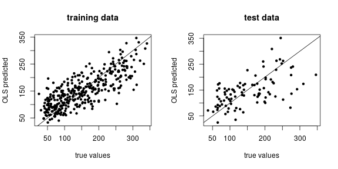

```r
plot(training_d$y, predict(ols), xlab="true values", ylab="OLS predicted", main="training data", pch=20)
abline(0,1)
plot(test_d$y, ols_pred, xlab="true values", ylab="OLS predicted", main="test data", pch=20)
abline(0,1)
```

## A sparsifying prior

We have a lot of predictors: 64 of them. A good guess is that only a few are really useful. So, we can put a *sparsifying* prior on the coefficients, i.e., $\beta$s in
$$\begin{aligned}
y = \beta_0 + \beta_1 x_1 + \cdots \beta_n x_n + \epsilon
\end{aligned}$$

# Crossvalidation: the effect of spurious variables

## Who says we don’t do experiments?

1. Simulate data with `y ~ a + b x[1] + c x[2]`, and fit a linear model.
2. Measure in-sample and out-of-sample prediction error.
3. Add spurious variables, and report the above as a function of number of variables.
4. Simulate data with *many, weakly predictive* explanatory variables.
5. Compare different methods for fitting linear models.

## Basic data: $y = a + b_1 x_1 + b_2 x_2 + \epsilon$.

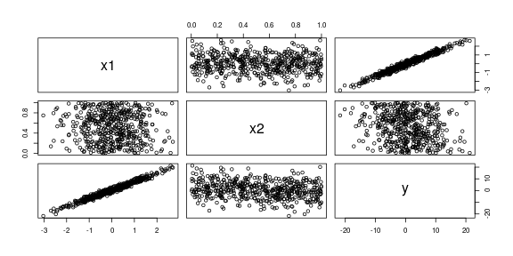

```r
N <- 500
df <- data.frame(x1 = rnorm(N),
                 x2 = runif(N))
params <- list(intercept = 2.0,
               x1 = 7.0,
               x2 = -3.0,
               sigma = 0.1 * 10)
pred_y <- params$intercept + params$x1 * df$x1 + params$x2 * df$x2
df$y <- rnorm(N, mean=pred_y, sd=params$sigma)
pairs(df)
```

## Crossvalidation error function

```r
kfold <- function (K, df) {
    N <- nrow(df)
    Kfold <- sample(rep(1:K, N/K))

    do_xval <- function (k) {
        the_lm <- lm(y ~ ., data=df, subset=(Kfold != k))
        train_error <- sqrt(mean(resid(the_lm)^2))
        test_y <- df$y[Kfold == k]
        test_error <- sqrt(mean( (test_y - predict(the_lm, newdata=subset(df, Kfold==k)))^2 ))
        return(c('test'=test_error, 'train'=train_error))
    }

    results <- sapply(1:K, do_xval)
    return(results)
}
```

## Add noise

```r
K <- 10
max_M <- 300
do_m <- floor(seq(from=2, to=max_M-1, length.out=40))
all_results <- matrix(NA, nrow=length(do_m) + 1, ncol=2)
first_results <- rowMeans(kfold(K, df))
all_results[1,] <- first_results
colnames(all_results) <- names(first_results)
```

```r
noise_df <- matrix(rnorm(N * (N-2)), nrow=N)
colnames(noise_df) <- paste0('z', 1:ncol(noise_df))
new_df <- cbind(df, noise_df)
for (j in seq_along(do_m)) {
    m <- do_m[j]
    all_results[j,] <- rowMeans(kfold(K, new_df[,1:(m+1)]))
}
```

## Results

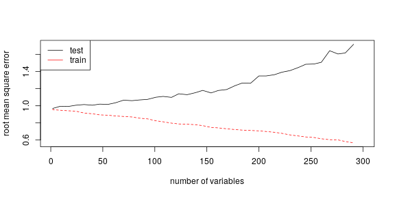

```r
matplot(c(2, do_m), all_results, type='l', xlab='number of variables', ylab='root mean square error')
legend("topleft", lty=1, col=1:2, legend=colnames(all_results))
```

# Sparseness and scale mixtures

## Encouraging sparseness

Suppose we do regression with a *large* number of predictor variables.

The resulting coefficients are **sparse** if most are zero.

The idea is to “encourage” all the coefficients to be zero, **unless** they *really* want to be nonzero, in which case we let them be whatever they want.

This tends to discourage overfitting.

> The idea is to “encourage” all the coefficients to be zero, **unless** they *really* want to be nonzero, in which case we let them be whatever they want.

To do this, we want a prior which is very peak-ey at zero *but* flat away from zero (“spike-and-slab”).

Compare the Normal

$$\begin{aligned}
X \sim \Normal(0,1)
\end{aligned}$$

to the “exponential scale mixture of Normals”,

$$\begin{aligned}
X &\sim \Normal(0,\sigma) \\
\sigma &\sim \Exp(1) .
\end{aligned}$$

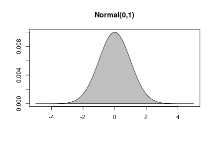

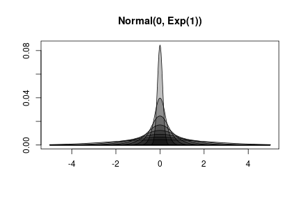

## Why use a scale mixture?

1. Lets the data choose the appropriate scale of variation.
2. Weakly encourages $\sigma$ to be small: so, as much variation as possible is explained by *signal* instead of *noise*.
3. Gets you a prior that is more peaked at zero and flatter otherwise.

## Implementation

Note that

$$\begin{aligned}
\beta &\sim \Normal(0,\sigma) \\
\sigma &\sim \Exp(1) .
\end{aligned}$$

is equivalent to

$$\begin{aligned}
\beta &= \sigma \gamma \\
\gamma &\sim \Normal(0,1) \\
\sigma &\sim \Exp(1) .
\end{aligned}$$

```
parameters {
    real beta;
    real<lower=0> sigma;
}
model {
    beta ~ normal(0, sigma);
    sigma ~ exponential(1);
}
```

is equivalent to

```
parameters {
    real gamma;
    real<lower=0> sigma;
}
transformed parameters {
    real beta;
    beta = gamma * sigma;
}
model {
    gamma ~ normal(0, 1);
    sigma ~ exponential(1);
}
```

The second version **is better** for Stan.

Why is it better?

```
parameters {
    real beta;
    real<lower=0> sigma;
}
model {
    beta ~ normal(0, sigma);
    sigma ~ exponential(1);
}
```

In the first, the optimal step size *depends on `sigma`*.

```
parameters {
    real gamma;
    real<lower=0> sigma;
}
transformed parameters {
    real beta;
    beta = gamma * sigma;
}
model {
    gamma ~ normal(0, 1);
    sigma ~ exponential(1);
}
```

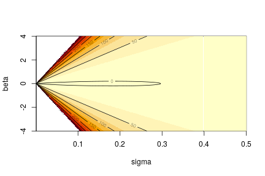

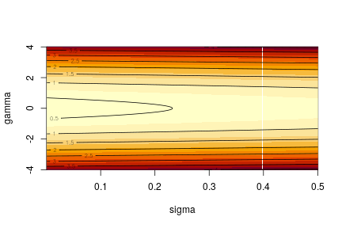

## A strongly sparsifying prior

The “horseshoe”:

$$\begin{aligned}
\beta_j &\sim \Normal(0, \lambda_j) \\
\lambda_j &\sim \Cauchy(0, \tau) \\
\tau &\sim \Unif(0, 1)
\end{aligned}$$

```
parameters {
    vector[p] d_beta;
    vector[p] d_lambda;
    real<lower=0, upper=1> tau;
}
transformed parameters {
    vector[p] beta;
    beta = d_beta .* d_lambda * tau;
}
model {
    d_beta ~ normal(0, 1);
    d_lambda ~ cauchy(0, 1);
    // tau ~ uniform(0, 1); // uniform
}
```

## The Cauchy as a scale mixture

Recall that if

$$\begin{aligned}
\beta &\sim \Normal(0, 1/\sqrt{\lambda}) \\
\lambda &\sim \Gam(1/2, 1/2)
\end{aligned}$$

then

$$\begin{aligned}
\beta &\sim \Cauchy(0, 1).
\end{aligned}$$

# With brms

## OLS in brms

```r
xy <- cbind(data.frame(y=diabetes$y), diabetes$x2)
names(xy) <- gsub("[:^]", "_", names(xy))

# ols
blm <- brm(y ~ ., data=xy, family=gaussian(link='identity'))
```

## horseshoe in brms

```r
bhs <- brm(y ~ ., data=xy, family=gaussian(link='identity'),
           prior=c(set_prior(horseshoe(), class="b")))
(klm <- brms::kfold(blm, K=5))
```

```
## Fitting model 1 out of 5
```

```
## Fitting model 2 out of 5
```

```
## Fitting model 3 out of 5
```

```
## Fitting model 4 out of 5
```

```
## Fitting model 5 out of 5
```

```
##
## Based on 5-fold cross-validation
##
##            Estimate   SE
## elpd_kfold  -2427.0 14.2
## p_kfold          NA   NA
## kfoldic      4854.1 28.4
```

```r
(khs <- brms::kfold(bhs, K=5))
```

```
## Fitting model 1 out of 5
```

```
## Fitting model 2 out of 5
```

```
## Fitting model 3 out of 5
```

```
## Fitting model 4 out of 5
```

```
## Fitting model 5 out of 5
```

```
##
## Based on 5-fold cross-validation
##
##            Estimate   SE
## elpd_kfold  -2399.6 13.6
## p_kfold          NA   NA
## kfoldic      4799.3 27.2
```

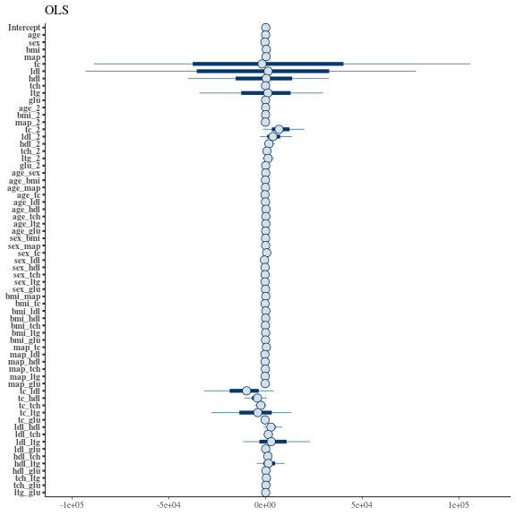

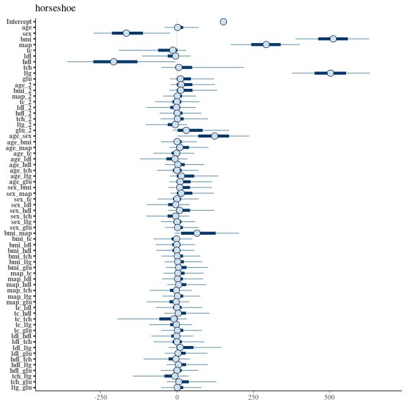

# Interlude

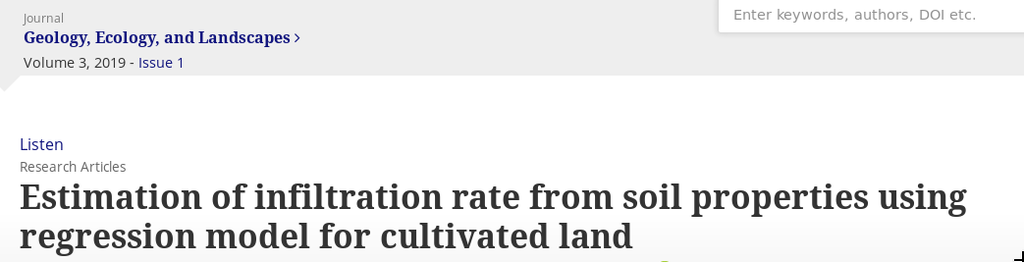

Estimation of infiltration rate from soil properties using regression model for cultivated land

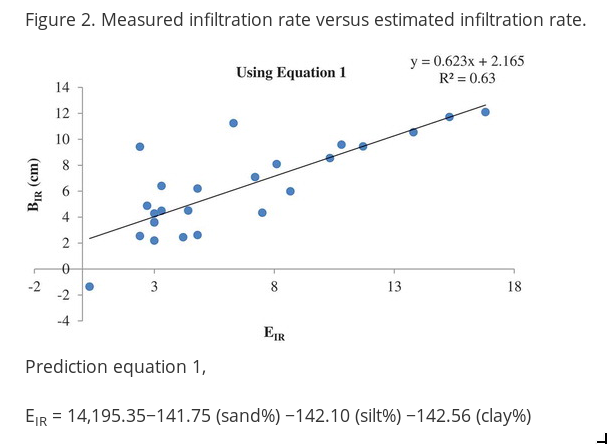

EIR = 14,195.35 - 141.75 (sand%) - 142.10 (silt%) - 142.56 (clay%)

Use the data to try to reproduce their model:

```
BIR = 14,195.35 - 141.75 (sand%) - 142.10 (silt%) - 142.56 (clay%)
```

They’re not wrong! What’s going on?

# Using the horseshoe

## What’s an appropriate noise distribution?

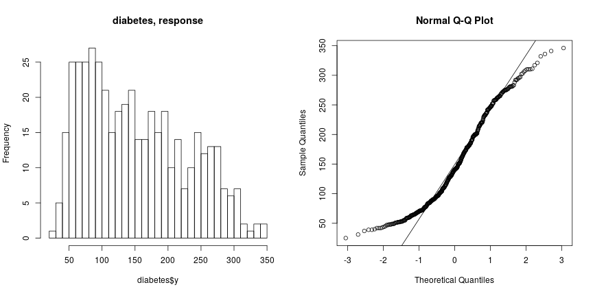

## Aside: quantile-quantile plots

The idea is to plot the *quantiles* of each distribution against each other.

If these are *datasets*, this means just plotting their *sorted values* against each other.

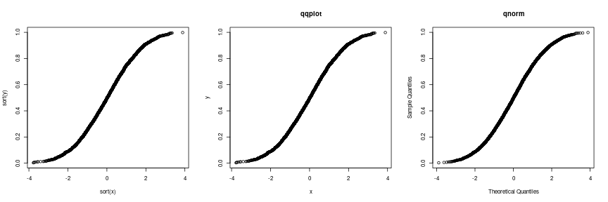

```r
x <- rnorm(1e4)
y <- rbeta(1e4, 2, 2)
plot(sort(x), sort(y)); qqplot(x, y, main="qqplot"); qqnorm(y, main="qnorm")
```

## Regression with a horseshoe prior

Uses a [reparameterization](https://betanalpha.github.io/assets/case_studies/fitting_the_cauchy.html) of the Cauchy as a scale mixture of normals.

```r
horseshoe_block <- "
data {
    int N;
    int p;
    vector[N] y;
    matrix[N,p] x;
}
parameters {
    real b0;
    vector[p] d_beta;
    vector[p] d_a;
    vector<lower=0>[p] d_b;
    real<lower=0, upper=1> tau;
    real<lower=0> sigma;
}
transformed parameters {
    vector[p] beta;
    vector[N] f;
    beta = d_beta .* d_a .* sqrt(d_b) * tau;
    f = b0 + x * beta;
}
model {
    y ~ normal(f, sigma);
    // HORSESHOE PRIOR:
    d_beta ~ normal(0, 1);
    d_a ~ normal(0, 1);
    d_b ~ inv_gamma(0.5, 0.5);
    // tau ~ uniform(0, 1); // uniform
    // priors on noise distribution:
    sigma ~ normal(0, 10);
}"
```

Note the data have already been normalized, with the exception of $y$:

```r
summary(training_d)
```

```
##        y            age              sex              bmi              map               tc              ldl              hdl              tch              ltg              glu             age^2
##  Min.   : 25   Min.   :-0.107   Min.   :-0.045   Min.   :-0.089   Min.   :-0.109   Min.   :-0.109   Min.   :-0.116   Min.   :-0.102   Min.   :-0.076   Min.   :-0.126   Min.   :-0.138   Min.   :-0.041
##  1st Qu.: 84   1st Qu.:-0.038   1st Qu.:-0.045   1st Qu.:-0.034   1st Qu.:-0.033   1st Qu.:-0.033   1st Qu.:-0.029   1st Qu.:-0.036   1st Qu.:-0.039   1st Qu.:-0.035   1st Qu.:-0.034   1st Qu.:-0.037
##  Median :141   Median : 0.005   Median :-0.045   Median :-0.007   Median :-0.006   Median :-0.004   Median :-0.004   Median :-0.007   Median :-0.003   Median :-0.004   Median : 0.003   Median :-0.020
##  Mean   :152   Mean   :-0.001   Mean   : 0.000   Mean   : 0.001   Mean   :-0.001   Mean   : 0.000   Mean   : 0.001   Mean   :-0.001   Mean   : 0.002   Mean   : 0.000   Mean   : 0.001   Mean   :-0.001
##  3rd Qu.:214   3rd Qu.: 0.034   3rd Qu.: 0.051   3rd Qu.: 0.034   3rd Qu.: 0.032   3rd Qu.: 0.027   3rd Qu.: 0.031   3rd Qu.: 0.027   3rd Qu.: 0.034   3rd Qu.: 0.034   3rd Qu.: 0.032   3rd Qu.: 0.017
##  Max.   :341   Max.   : 0.111   Max.   : 0.051   Max.   : 0.171   Max.   : 0.132   Max.   : 0.154   Max.   : 0.199   Max.   : 0.181   Max.   : 0.185   Max.   : 0.134   Max.   : 0.136   Max.   : 0.183
##      bmi^2           map^2             tc^2            ldl^2           hdl^2           tch^2           ltg^2            glu^2           age:sex          age:bmi          age:map           age:tc
##  Min.   :-0.03   Min.   :-0.039   Min.   :-0.032   Min.   :-0.03   Min.   :-0.03   Min.   :-0.03   Min.   :-0.035   Min.   :-0.032   Min.   :-0.121   Min.   :-0.147   Min.   :-0.166   Min.   :-0.136
##  1st Qu.:-0.03   1st Qu.:-0.035   1st Qu.:-0.029   1st Qu.:-0.03   1st Qu.:-0.02   1st Qu.:-0.03   1st Qu.:-0.030   1st Qu.:-0.029   1st Qu.:-0.031   1st Qu.:-0.022   1st Qu.:-0.020   1st Qu.:-0.021
##  Median :-0.02   Median :-0.020   Median :-0.018   Median :-0.02   Median :-0.01   Median :-0.01   Median :-0.017   Median :-0.017   Median : 0.001   Median :-0.007   Median :-0.009   Median :-0.010
##  Mean   : 0.00   Mean   :-0.002   Mean   :-0.001   Mean   : 0.00   Mean   : 0.00   Mean   : 0.00   Mean   : 0.001   Mean   : 0.001   Mean   : 0.000   Mean   : 0.000   Mean   : 0.000   Mean   :-0.003
##  3rd Qu.: 0.02   3rd Qu.: 0.018   3rd Qu.: 0.005   3rd Qu.: 0.01   3rd Qu.: 0.01   3rd Qu.:-0.01   3rd Qu.: 0.017   3rd Qu.: 0.011   3rd Qu.: 0.035   3rd Qu.: 0.019   3rd Qu.: 0.021   3rd Qu.: 0.015
##  Max.   : 0.39   Max.   : 0.264   Max.   : 0.303   Max.   : 0.49   Max.   : 0.37   Max.   : 0.43   Max.   : 0.241   Max.   : 0.236   Max.   : 0.112   Max.   : 0.170   Max.   : 0.228   Max.   : 0.185
##     age:ldl          age:hdl          age:tch          age:ltg          age:glu          sex:bmi          sex:map           sex:tc          sex:ldl          sex:hdl          sex:tch          sex:ltg
##  Min.   :-0.155   Min.   :-0.180   Min.   :-0.201   Min.   :-0.160   Min.   :-0.120   Min.   :-0.126   Min.   :-0.140   Min.   :-0.121   Min.   :-0.130   Min.   :-0.166   Min.   :-0.160   Min.   :-0.143
##  1st Qu.:-0.021   1st Qu.:-0.025   1st Qu.:-0.018   1st Qu.:-0.022   1st Qu.:-0.021   1st Qu.:-0.036   1st Qu.:-0.033   1st Qu.:-0.032   1st Qu.:-0.032   1st Qu.:-0.034   1st Qu.:-0.020   1st Qu.:-0.034
##  Median :-0.008   Median : 0.001   Median :-0.009   Median :-0.008   Median :-0.010   Median :-0.002   Median : 0.001   Median :-0.001   Median :-0.001   Median :-0.004   Median : 0.008   Median : 0.004
##  Mean   :-0.002   Mean   :-0.003   Mean   : 0.000   Mean   : 0.000   Mean   : 0.002   Mean   : 0.000   Mean   :-0.001   Mean   :-0.002   Mean   :-0.001   Mean   :-0.001   Mean   : 0.001   Mean   :-0.001
##  3rd Qu.: 0.014   3rd Qu.: 0.017   3rd Qu.: 0.021   3rd Qu.: 0.020   3rd Qu.: 0.017   3rd Qu.: 0.034   3rd Qu.: 0.035   3rd Qu.: 0.031   3rd Qu.: 0.029   3rd Qu.: 0.030   3rd Qu.: 0.022   3rd Qu.: 0.032
##  Max.   : 0.206   Max.   : 0.180   Max.   : 0.284   Max.   : 0.187   Max.   : 0.184   Max.   : 0.179   Max.   : 0.104   Max.   : 0.162   Max.   : 0.206   Max.   : 0.162   Max.   : 0.191   Max.   : 0.136
##     sex:glu          bmi:map           bmi:tc          bmi:ldl          bmi:hdl          bmi:tch          bmi:ltg          bmi:glu           map:tc          map:ldl          map:hdl          map:tch
##  Min.   :-0.140   Min.   :-0.125   Min.   :-0.293   Min.   :-0.287   Min.   :-0.268   Min.   :-0.132   Min.   :-0.185   Min.   :-0.154   Min.   :-0.202   Min.   :-0.204   Min.   :-0.283   Min.   :-0.145
##  1st Qu.:-0.033   1st Qu.:-0.021   1st Qu.:-0.019   1st Qu.:-0.022   1st Qu.:-0.019   1st Qu.:-0.024   1st Qu.:-0.024   1st Qu.:-0.024   1st Qu.:-0.020   1st Qu.:-0.020   1st Qu.:-0.020   1st Qu.:-0.018
##  Median :-0.005   Median :-0.011   Median :-0.008   Median :-0.008   Median : 0.011   Median :-0.016   Median :-0.012   Median :-0.015   Median :-0.009   Median :-0.007   Median : 0.005   Median :-0.010
##  Mean   :-0.002   Mean   : 0.002   Mean   : 0.000   Mean   : 0.001   Mean   : 0.000   Mean   : 0.001   Mean   : 0.000   Mean   : 0.000   Mean   :-0.002   Mean   :-0.001   Mean   :-0.001   Mean   : 0.000
##  3rd Qu.: 0.034   3rd Qu.: 0.017   3rd Qu.: 0.020   3rd Qu.: 0.016   3rd Qu.: 0.026   3rd Qu.: 0.021   3rd Qu.: 0.022   3rd Qu.: 0.019   3rd Qu.: 0.018   3rd Qu.: 0.018   3rd Qu.: 0.020   3rd Qu.: 0.021
##  Max.   : 0.133   Max.   : 0.228   Max.   : 0.227   Max.   : 0.232   Max.   : 0.146   Max.   : 0.276   Max.   : 0.219   Max.   : 0.225   Max.   : 0.190   Max.   : 0.192   Max.   : 0.141   Max.   : 0.229
```

[output cut: 14 more lines]

```r
horseshoe_fit <- stan(model_code=horseshoe_block,
                      data=list(N=nrow(training_d),
                                p=ncol(training_d)-1,
                                y=(training_d$y
                                   - median(training_d$y))
                                  /mad(training_d$y),
                                x=as.matrix(training_d[,-1])),
                      iter=1000,
                      control=list(adapt_delta=0.999,
                                   max_treedepth=15))
(hs_summary <- rstan::summary(horseshoe_fit, pars=c("b0", "sigma", "beta"))$summary)
```

```
##              mean se_mean    sd   2.5%      25%      50%    75%  98% n_eff Rhat
## b0        0.11847 0.00054 0.031  0.058  0.09724  0.11828  0.141 0.18  3347    1
## sigma     0.59494 0.00048 0.024  0.549  0.57915  0.59438  0.610 0.64  2477    1
## beta[1]   0.18468 0.01081 0.441 -0.439 -0.04236  0.05639  0.330 1.36  1669    1
## beta[2]  -1.27036 0.03230 1.000 -3.355 -1.98366 -1.22500 -0.383 0.12   959    1
## beta[3]   5.97824 0.02349 0.928  4.142  5.36459  5.99472  6.606 7.83  1561    1
## beta[4]   3.43216 0.03138 0.990  1.345  2.83589  3.46677  4.079 5.29   996    1
## beta[5]  -0.23122 0.02070 0.669 -1.934 -0.34336 -0.04547  0.047 0.65  1045    1
## beta[6]  -0.00017 0.01544 0.560 -1.000 -0.14021 -0.00303  0.109 0.96  1317    1
## beta[7]  -1.31586 0.03931 1.197 -3.845 -2.21610 -1.14696 -0.159 0.18   928    1
## beta[8]   0.30767 0.02202 0.755 -0.590 -0.03962  0.05539  0.410 2.67  1177    1
## beta[9]   5.71389 0.02644 1.018  3.725  5.03216  5.68509  6.420 7.72  1484    1
## beta[10]  0.26253 0.01448 0.518 -0.414 -0.02317  0.07275  0.423 1.73  1278    1
## beta[11]  0.23320 0.01261 0.482 -0.416 -0.02111  0.07704  0.393 1.58  1463    1
## beta[12]  0.14319 0.01199 0.442 -0.587 -0.04693  0.03456  0.267 1.36  1361    1
## beta[13]  0.03119 0.01080 0.339 -0.672 -0.08882  0.00737  0.129 0.85   987    1
## beta[14] -0.02838 0.01354 0.486 -1.202 -0.16016 -0.00246  0.121 1.02  1288    1
## beta[15] -0.08398 0.01429 0.535 -1.337 -0.17772 -0.01292  0.084 0.91  1400    1
## beta[16]  0.03915 0.01208 0.441 -0.915 -0.09980  0.00799  0.166 1.05  1333    1
## beta[17]  0.07360 0.01198 0.432 -0.698 -0.08954  0.01054  0.178 1.18  1302    1
## beta[18] -0.28898 0.01467 0.545 -1.751 -0.46633 -0.09520  0.014 0.39  1382    1
## beta[19]  0.78015 0.02871 0.871 -0.278  0.04895  0.51543  1.368 2.74   920    1
## beta[20]  1.47129 0.02600 0.938 -0.032  0.72236  1.48715  2.159 3.26  1301    1
## beta[21]  0.20772 0.01309 0.481 -0.499 -0.03633  0.06031  0.352 1.52  1351    1
## beta[22]  0.26289 0.01393 0.512 -0.417 -0.01699  0.09774  0.455 1.67  1349    1
## beta[23]  0.00158 0.01182 0.417 -0.879 -0.11609  0.00167  0.134 0.84  1245    1
## beta[24] -0.10350 0.01260 0.462 -1.316 -0.21664 -0.01530  0.069 0.68  1344    1
## beta[25]  0.03007 0.01111 0.385 -0.725 -0.10381  0.00717  0.153 0.92  1199    1
## beta[26]  0.04793 0.01247 0.434 -0.792 -0.10275  0.00745  0.172 1.06  1213    1
## beta[27]  0.35088 0.01561 0.605 -0.384 -0.00555  0.11684  0.572 1.98  1502    1
## beta[28]  0.28770 0.01490 0.555 -0.429 -0.01956  0.09428  0.492 1.84  1388    1
## beta[29]  0.55050 0.01892 0.715 -0.249  0.00938  0.29048  0.930 2.34  1426    1
## beta[30]  0.16897 0.01170 0.444 -0.483 -0.03571  0.04440  0.289 1.40  1440    1
## beta[31]  0.07436 0.01259 0.429 -0.668 -0.09090  0.01118  0.166 1.21  1162    1
## beta[32] -0.13863 0.01324 0.446 -1.328 -0.25271 -0.03182  0.059 0.59  1134    1
## beta[33]  0.41573 0.01688 0.645 -0.315 -0.00077  0.16688  0.666 2.14  1461    1
## beta[34] -0.13366 0.01228 0.452 -1.323 -0.27521 -0.03291  0.057 0.59  1354    1
## beta[35]  0.06844 0.01060 0.375 -0.656 -0.07767  0.00983  0.189 0.99  1251    1
## beta[36]  0.00597 0.00986 0.351 -0.773 -0.11192  0.00097  0.135 0.76  1267    1
## beta[37]  0.84159 0.02197 0.878 -0.203  0.08052  0.59820  1.447 2.82  1598    1
```

[output cut: 12 more lines]

```
## beta[50] -0.01323 0.01286 0.501 -1.080 -0.15172 -0.00465  0.112 0.98  1518    1
## beta[51]  0.07131 0.01251 0.448 -0.667 -0.09582  0.01067  0.167 1.19  1282    1
## beta[52] -0.37967 0.02132 0.758 -2.461 -0.54911 -0.09195  0.024 0.46  1263    1
## beta[53] -0.13073 0.01312 0.498 -1.500 -0.22152 -0.01822  0.072 0.63  1438    1
## beta[54]  0.05582 0.01172 0.435 -0.805 -0.08886  0.01069  0.173 1.10  1377    1
## beta[55] -0.07641 0.01428 0.466 -1.315 -0.17775 -0.00895  0.094 0.71  1063    1
## beta[56] -0.03597 0.01354 0.468 -1.096 -0.16718 -0.00506  0.109 0.96  1196    1
## beta[57]  0.23560 0.01706 0.606 -0.483 -0.04384  0.04846  0.352 2.00  1262    1
## beta[58]  0.02036 0.01282 0.432 -0.871 -0.12112  0.00130  0.143 0.96  1136    1
## beta[59] -0.15576 0.01334 0.488 -1.542 -0.25669 -0.02821  0.057 0.61  1340    1
## beta[60]  0.10674 0.01163 0.417 -0.574 -0.06224  0.02681  0.212 1.20  1284    1
## beta[61]  0.01456 0.01035 0.364 -0.768 -0.11944  0.00029  0.129 0.86  1233    1
## beta[62] -0.14660 0.01325 0.492 -1.361 -0.26495 -0.02706  0.060 0.70  1379    1
## beta[63]  0.12335 0.01578 0.496 -0.704 -0.07143  0.02268  0.233 1.49   989    1
## beta[64]  0.15840 0.01482 0.490 -0.603 -0.05885  0.03289  0.306 1.50  1092    1
```

First compare the resulting regression parameters to OLS values.

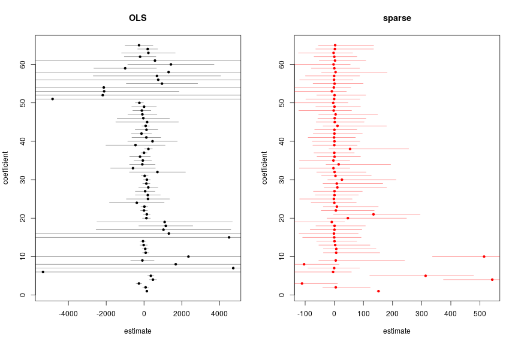

The coefficient estimates from OLS are *wierd*.

```
##                  ols     stan    brms
## (Intercept)   150.69  151.697  152.12
## tc          -5344.14   -4.112  -39.32
## `tc:ldl`    -4837.76   -0.420    2.57
## ldl          4723.00   -0.274  -15.40
## `tc^2`       4501.31   -0.222    0.41
## ltg          2350.56  514.151  503.02
## `tc:hdl`    -2183.97    0.965   15.63
## `tc:ltg`    -2127.48   -1.647   -9.43
## `tc:tch`    -2109.49   -8.316  -37.94
## hdl          1680.54 -103.729 -198.07
## `hdl:tch`    1423.43   -2.551  -15.64
## `ldl^2`      1315.35   -1.168   -8.08
## `ldl:ltg`    1301.03    4.383   31.38
## `tch^2`      1153.51    0.953    9.84
## `ltg^2`      1092.08   -8.610  -16.80
## `hdl^2`      1030.42    0.723    4.75
## `ldl:glu`    -997.18    0.118   14.30
## `tc:glu`      950.94    0.967    7.18
## `ldl:hdl`     750.67   -0.809   -6.66
## `sex:tc`      710.47    1.011    1.77
## `ldl:tch`     685.72   -0.458    2.79
## `sex:ldl`    -583.09   -2.878  -14.72
## `hdl:ltg`     579.69    2.424   16.42
## bmi           472.78  542.154  510.40
## `bmi:tc`     -449.81    0.024   -6.41
## `bmi:ldl`     449.71    0.577   -2.40
## `age:tc`     -381.44    0.151   -4.40
## map           360.87  313.530  290.61
## sex          -269.63 -110.788 -160.69
## `ltg:glu`    -262.97    2.975    7.05
## `map:glu`    -244.48   -3.539  -11.83
## `bmi:map`     232.78   54.101   77.03
## `tch:ltg`     231.58   -2.447  -24.62
## `age:ltg`     226.96   10.567   32.23
## `age:ldl`     210.22   -1.384  -20.88
## `sex:ltg`    -210.10    0.889    2.05
## `hdl:glu`    -207.19    0.027    3.76
## `age:hdl`     200.91    0.648   12.25
## `tch:glu`     195.25    2.051   22.71
```

[output cut: 11 more lines]

```
## `bmi:glu`      88.77   10.922   16.41
## tch           -85.18    5.010   34.45
## age            84.95    5.100    7.73
## `map:hdl`     -84.93    4.484   16.25
## `age^2`        66.33    6.968   28.84
## `sex:tch`     -61.99   -2.976  -15.37
## `age:tch`      61.39    0.673    0.95
## `map^2`       -52.39    0.667    4.76
## `map:ldl`     -35.37    1.421    7.81
## `sex:map`      34.90    4.016   28.94
## `age:map`      20.59    8.839   22.15
## `bmi^2`       -15.81    3.125   29.56
## `map:ltg`       3.84    0.648    7.32
## `sex:glu`       2.21    0.088    8.23
## `age:bmi`       0.26    5.454    3.13
```

And, quite different than what Stan gets.

```
##                  ols     stan    brms
## (Intercept)   150.69  151.697  152.12
## bmi           472.78  542.154  510.40
## ltg          2350.56  514.151  503.02
## map           360.87  313.530  290.61
## `age:sex`     148.20  134.496  120.77
## sex          -269.63 -110.788 -160.69
## hdl          1680.54 -103.729 -198.07
## `bmi:map`     232.78   54.101   77.03
## `glu^2`       128.34   46.615   49.61
## `sex:bmi`     151.25   26.270   23.66
## `sex:hdl`     -89.04   15.092   24.71
## `bmi:glu`      88.77   10.922   16.41
## `age:ltg`     226.96   10.567   32.23
## `age:map`      20.59    8.839   22.15
## `ltg^2`      1092.08   -8.610  -16.80
## `age:glu`     123.57    8.527   25.26
## `tc:tch`    -2109.49   -8.316  -37.94
## `age^2`        66.33    6.968   28.84
## glu            89.65    6.579   26.70
## `age:bmi`       0.26    5.454    3.13
## age            84.95    5.100    7.73
## tch           -85.18    5.010   34.45
## `map:hdl`     -84.93    4.484   16.25
## `ldl:ltg`    1301.03    4.383   31.38
## tc          -5344.14   -4.112  -39.32
## `sex:map`      34.90    4.016   28.94
## `map:glu`    -244.48   -3.539  -11.83
## `bmi^2`       -15.81    3.125   29.56
## `sex:tch`     -61.99   -2.976  -15.37
## `ltg:glu`    -262.97    2.975    7.05
## `sex:ldl`    -583.09   -2.878  -14.72
## `hdl:tch`    1423.43   -2.551  -15.64
## `tch:ltg`     231.58   -2.447  -24.62
## `hdl:ltg`     579.69    2.424   16.42
## `tch:glu`     195.25    2.051   22.71
## `map:tch`    -114.15   -2.020   -9.89
## `tc:ltg`    -2127.48   -1.647   -9.43
## `map:tc`      164.89    1.549   11.64
## `map:ldl`     -35.37    1.421    7.81
```

[output cut: 11 more lines]

```
## `map^2`       -52.39    0.667    4.76
## `age:hdl`     200.91    0.648   12.25
## `map:ltg`       3.84    0.648    7.32
## `bmi:ldl`     449.71    0.577   -2.40
## `bmi:tch`    -132.98    0.469    6.28
## `bmi:ltg`     132.11    0.466   10.37
## `ldl:tch`     685.72   -0.458    2.79
## `tc:ldl`    -4837.76   -0.420    2.57
## ldl          4723.00   -0.274  -15.40
## `tc^2`       4501.31   -0.222    0.41
## `age:tc`     -381.44    0.151   -4.40
## `ldl:glu`    -997.18    0.118   14.30
## `sex:glu`       2.21    0.088    8.23
## `hdl:glu`    -207.19    0.027    3.76
## `bmi:tc`     -449.81    0.024   -6.41
```

Now let’s look at out-of-sample prediction error, using the posterior median coefficient estimates:

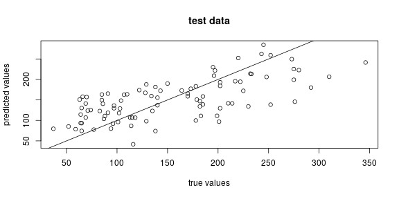

```r
pred_stan <- function (x) {
    post_med_intercept + as.matrix(x) %*% post_med_slopes
}
pred_y <- pred_stan(test_d[,-1])
stan_pred_error <- sqrt(mean((test_d$y - pred_y)^2))
stan_mse_resid <- sqrt(mean((training_d$y - pred_stan(training_d[,-1]))^2))

plot(test_d$y, pred_y, xlab="true values", ylab="predicted values", main="test data")
abline(0,1)
```

## Conclusions?

1. Our “sparse” model is certainly more sparse, and arguably more interpretable.
2. It has a root-mean-square prediction error of 52.42 on the *test* data, and 52.92 on the training data.
3. This is substantially better than ordinary linear regression, which had a root-mean-square prediction error of 61.35 on the test data, and a root-mean-square-error of 47.91 on the training data.

The sparse model is more interpretable, and more generalizable.

# Midterm review

## Steps in data analysis

1. Care, or at least think, about the data.
2. Look at the data.
3. Query the data.
4. Sanity check.
5. Communicate.

Often “statistics” focuses on *querying*. Doing that effectively requires all the other steps, too.

## Statistics or parameters?

**A **statistic** is**

a numerical description of a dataset.

**A **parameter** is**

a numerical attribute of a model of reality.

Often, *statistics* are used to estimate *parameters*.

## The two+ heads of classical statistics

estimating parameters, with uncertainty (*confidence* or *credible intervals*)

evaluating (in-)consistency with a particular situation (*$p$-values*)

prediction, with uncertainty

model adequacy and fit (simulation, crossvalidation)

## Models, part 1: How do we do this?

Parameters are *numbers*. With *units*.

So, they need to mean something *concrete* and *precise*.

In other words, they need to be part of a *model*.

## Models, part 2: Noise, and uncertainty.

To separate *information* from *noise*, we need to understand the noise.

*How much of these differences are due to measurement error? or, unpredictable variation? How much is telling me something about the world?*

A full model also describes the *statistical noise* in the data.

(It’s a full model if you can simulate from it.)

## Models, part 3: how to fit them.

**Fitting a model:** Finding parameter values that make the data look plausible.

There may be a *wide range* of plausible parameter values.

*Priors* help get answers.

## Aspects of a model

1. What variables?
2. Response distribution(s).
3. Relationship of predictors to the response(s).
4. Relationships between parameters.

*Every* statistical method has a model lurking somewhere behind it.

## How do we fit models?

The basic tool is **likelihood**:

how likely are the data, using this set of parameters?

*Some methods:*

1. Hill climbing (maximum likelihood).
2. Hill wandering (Monte Carlo to explore posterior distributions)